Load EFA/CFA:

```r
load("01B_out_efacfa_2021-03-03-1824-31.RData")

library(kableExtra)
library(ggplot2)
library(LAM)
library(psych)
library(lavaan)

source("01C_functions.R")
```

Open relevant tab:

```r
itab = "TPFQ" # Set manually!
iresults =  results[[itab]]
idata = data_tabs[[itab]]
ilookup = lookups_all[[itab]]
q_legacy = ncol(ilookup)-2
```

Get Goodness of fit (gof):

```r
gof_type = "cumss" # Set manually!
# gof_type = "mle_dist" # Set manually!
efa_gof = sapply(iresults$efa, get_efa_gof, gof_type=gof_type)
efa_bic = sapply(iresults$efa, function(x) x$BIC) # poor measure
legacy_gof = c(
  "full"=get_cfa_gof(iresults$cfa$full$legacy, gof_type=gof_type)
  , "reduced"=get_cfa_gof(iresults$cfa$reduced$legacy, gof_type=gof_type)
)
rand_gof = data.frame(cbind(
  "full"=sapply(iresults$cfa$full$rand, get_cfa_gof, gof_type=gof_type)
  , "reduced"=sapply(iresults$cfa$reduced$rand, get_cfa_gof, gof_type=gof_type)
))
legacy_one_gof = data.frame(cbind(
  "full"=sapply(iresults$cfa$full$legacy_one, get_cfa_gof, gof_type=gof_type)
  , "reduced"=sapply(iresults$cfa$reduced$legacy_one, get_cfa_gof, gof_type=gof_type)
))
rownames(legacy_one_gof) = colnames(ilookup)[-c(1,2)]
legacy_qfactors = ncol(iresults$ilookup)-2
```

**Reduced vs Full:** When doing CFA we consider two models. The first is a reduced (sparse) model where $\Lambda$ is 0/1. The second is a full model where certain $\lambda_{ij}=0$ but the rest are unrestricted. In both cases we allow for an unrestricted $\Phi$. Done in Lavaan.

**EFA #:** We look at the EFA goodness of fit for different number of parameters. Horizontal lines for legacy subscales. *Purpose* Compared to the legacy subscales, how much better performance could be achieved with an EFA model? Since EFA is more flexible we expect it to fit better, but if it performs MUCH better this indicates the legacy subscale may be poor.

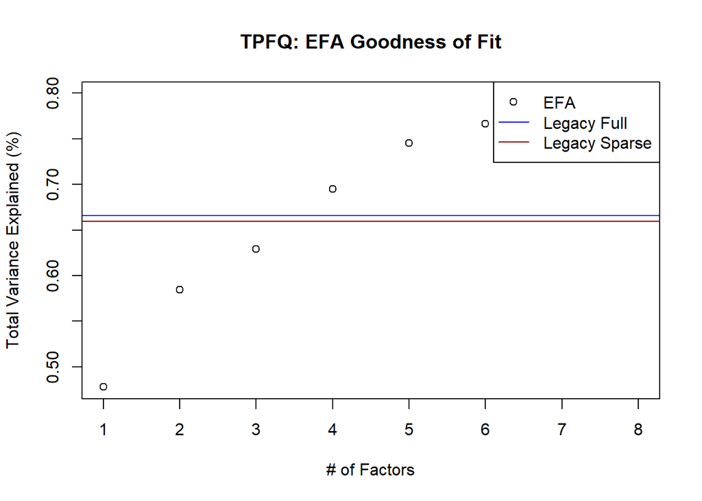

```r
# EFA
plot(efa_gof
     , xlab="# of Factors", ylab=gof_lookup[["desc"]][gof_type], main=paste0(itab, ": EFA Goodness of Fit")
     , ylim=get_lims(c(efa_gof, legacy_gof))
)
abline(h=legacy_gof["full"], col="blue")
abline(h=legacy_gof["reduced"], col="darkred")
legend("topright"
       , legend=c("EFA", "Legacy Full", "Legacy Sparse")
       , col=c("black", "blue", "darkred")
       , lty = c(0,1,1)
       , pch = c(1,NA,NA)
)
```

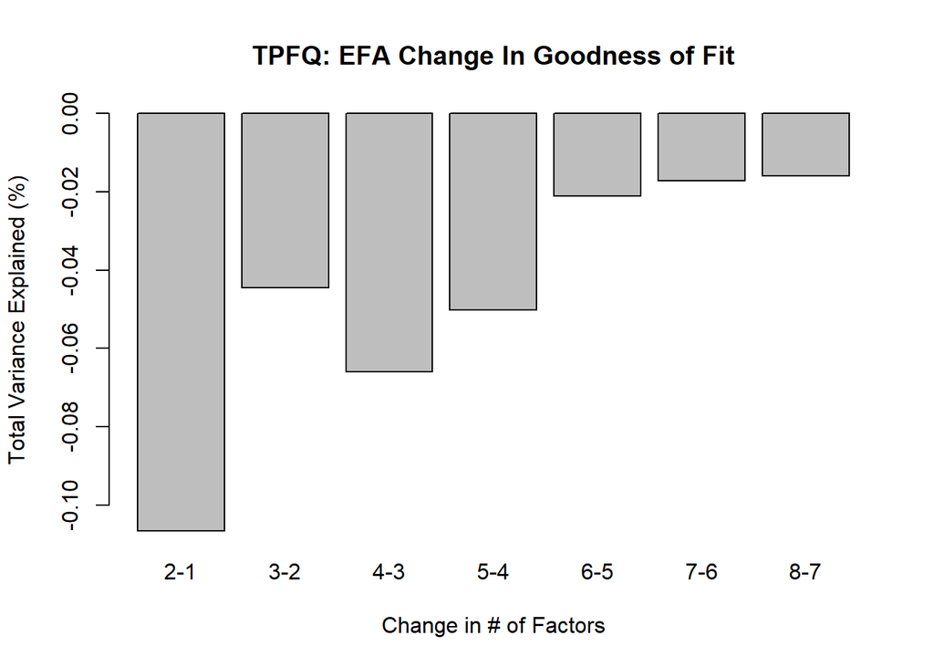

```r
barplot(
  height=-diff(efa_gof)
  , names.arg=paste0(2:(length(efa_gof)), "-", 1:(length(efa_gof)-1))
  , ylab=gof_lookup[["desc"]][gof_type]
  , xlab="Change in # of Factors"
  , main=paste0(itab, ": EFA Change In Goodness of Fit")
  )
```

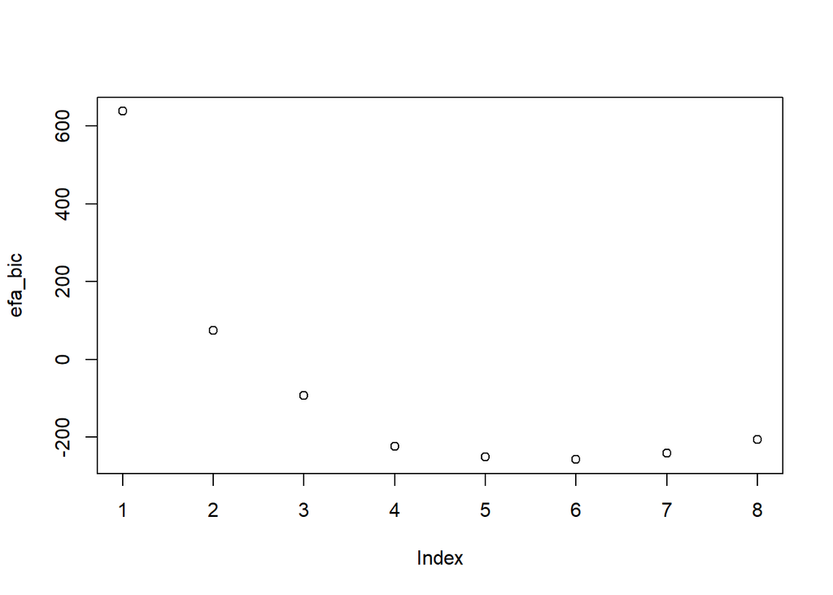

```r
plot(efa_bic)
```

**EFA Target:** Tabular comparison of legacy subscale vs same-size EFA (target rotation). *Purpose* Are the legacy subscales consistent with EFA? Consistency indicates a good legacy fit.

```r
# EFA target rotation
load_mat = loading_2_matrix(iresults$efa[[q_legacy]]$stat424_target$loadings)
out = cbind(ilookup
      , round(load_mat,3)
      , id_l=apply(ilookup, 1, function(irow) which(irow==1)-2)
      , id_efa=apply(abs(load_mat), 1, function(irow) which.max(irow))
)
kbl(out[,-2]) %>% kable_styling() %>% scroll_box(width = "800px", height = "500px") # Can add question description (column 2)
```

|  | ID | C_Concentration | E_Emotion | H_Hearing | S_Sleep | ML1 | ML2 | ML3 | ML4 | id_l | id_efa |
| --- | --- | --- | --- | --- | --- | --- | --- | --- | --- | --- | --- |
| TPFQ_Q1 | Q1 | 1 | 0 | 0 | 0 | 0.720 | 0.174 | 0.118 | -0.019 | 1 | 1 |
| TPFQ_Q2 | Q2 | 0 | 0 | 0 | 1 | 0.009 | -0.092 | 0.005 | 1.002 | 4 | 4 |
| TPFQ_Q3 | Q3 | 0 | 1 | 0 | 0 | 0.257 | 0.157 | 0.105 | 0.143 | 2 | 1 |
| TPFQ_Q4 | Q4 | 0 | 0 | 0 | 1 | 0.047 | -0.083 | -0.034 | 0.997 | 4 | 4 |
| TPFQ_Q5 | Q5 | 1 | 0 | 0 | 0 | 0.269 | 0.172 | 0.338 | 0.147 | 1 | 3 |
| TPFQ_Q6 | Q6 | 0 | 0 | 1 | 0 | -0.066 | -0.090 | 0.908 | 0.100 | 3 | 3 |
| TPFQ_Q7 | Q7 | 1 | 0 | 0 | 0 | 0.651 | 0.232 | -0.002 | -0.063 | 1 | 1 |
| TPFQ_Q8 | Q8 | 0 | 1 | 0 | 0 | 0.275 | 0.094 | 0.244 | 0.058 | 2 | 1 |
| TPFQ_Q9 | Q9 | 0 | 0 | 1 | 0 | 0.079 | 0.021 | 0.901 | -0.068 | 3 | 3 |
| TPFQ_Q10 | Q10 | 0 | 0 | 1 | 0 | -0.040 | 0.302 | 0.669 | -0.029 | 3 | 3 |
| TPFQ_Q11 | Q11 | 0 | 0 | 0 | 1 | -0.020 | 0.158 | 0.107 | 0.723 | 4 | 4 |
| TPFQ_Q12 | Q12 | 0 | 0 | 1 | 0 | 0.043 | 0.026 | 0.905 | -0.079 | 3 | 3 |
| TPFQ_Q13 | Q13 | 0 | 1 | 0 | 0 | -0.182 | 0.789 | 0.097 | 0.081 | 2 | 2 |
| TPFQ_Q14 | Q14 | 0 | 0 | 0 | 1 | 0.064 | 0.136 | -0.042 | 0.722 | 4 | 4 |
| TPFQ_Q15 | Q15 | 0 | 1 | 0 | 0 | 0.190 | 0.675 | -0.072 | 0.030 | 2 | 2 |
| TPFQ_Q16 | Q16 | 1 | 0 | 0 | 0 | 0.878 | 0.040 | -0.190 | 0.104 | 1 | 1 |
| TPFQ_Q17 | Q17 | 0 | 0 | 0 | 1 | -0.040 | 0.138 | -0.083 | 0.868 | 4 | 4 |
| TPFQ_Q18 | Q18 | 0 | 1 | 0 | 0 | 0.179 | 0.824 | -0.090 | -0.028 | 2 | 2 |
| TPFQ_Q19 | Q19 | 0 | 0 | 1 | 0 | 0.310 | 0.005 | 0.501 | 0.028 | 3 | 3 |
| TPFQ_Q20 | Q20 | 1 | 0 | 0 | 0 | 1.003 | 0.041 | 0.058 | -0.107 | 1 | 1 |

**EFA Best:** Can we interpret the ‘best’ EFA? *Purpose* We try to explain any differences between EFA and the legacy subscales.

```r
# EFA Best
# best_efa_id = c("THI"=3, "TPFQ"=4, "TFI"=5)[itab] # Set manually!
best_efa_id = legacy_qfactors
print(best_efa_id)
```

```
## [1] 4
```

```r
best_efa = iresults$efa[[best_efa_id]]
if (best_efa$factors==1){
  best_efa$stat424_oblimin = list("loadings"=loadings(best_efa))
}
out = cbind(
  ilookup[,c(1,2)]
  , round(loading_2_matrix(best_efa$stat424_oblimin$loadings),3)
)
kbl(out) %>% kable_styling() %>% scroll_box(width = "800px", height = "500px")
```

|  | ID | Question | ML1 | ML2 | ML3 | ML4 |
| --- | --- | --- | --- | --- | --- | --- |
| TPFQ_Q1 | Q1 | 1 I have difficulty focusing my attention on some important tasks because of tinnitus. | 0.057 | 0.166 | 0.672 | 0.125 |
| TPFQ_Q2 | Q2 | 2 I lie awake at night because of my tinnitus. | 0.981 | 0.029 | 0.015 | -0.082 |
| TPFQ_Q3 | Q3 | 3 I just wish my tinnitus would go away. It is so frustrating. | 0.173 | 0.130 | 0.243 | 0.136 |
| TPFQ_Q4 | Q4 | 4 I have difficulty getting to sleep at night because of my tinnitus. | 0.978 | -0.007 | 0.050 | -0.075 |
| TPFQ_Q5 | Q5 | 5 When there are lots of things happening at once, my tinnitus interferes with my ability to attend to the most important thing. | 0.186 | 0.362 | 0.256 | 0.147 |
| TPFQ_Q6 | Q6 | 6 My tinnitus masks some speech sounds. | 0.119 | 0.893 | -0.056 | -0.092 |
| TPFQ_Q7 | Q7 | 7 My inability to think about something undisturbed is one of the worst effects of my tinnitus. | 0.006 | 0.045 | 0.608 | 0.185 |
| TPFQ_Q8 | Q8 | 8 My tinnitus is annoying. | 0.093 | 0.264 | 0.259 | 0.072 |
| TPFQ_Q9 | Q9 | 9 One of the worst things about my tinnitus is its effect on my loss. speech understanding, over and above any effect of my hearing | -0.030 | 0.894 | 0.079 | 0.005 |
| TPFQ_Q10 | Q10 | 10 My tinnitus, not my hearing loss, interferes with my appreciation of music and songs. | 0.001 | 0.671 | -0.027 | 0.284 |
| TPFQ_Q11 | Q11 | 11 I am tired during the day because my tinnitus has disrupted my sleep. | 0.717 | 0.132 | -0.009 | 0.155 |
| TPFQ_Q12 | Q12 | 12 In addition to my hearing loss, my tinnitus interferes with my understanding of speech. | -0.044 | 0.897 | 0.045 | 0.012 |
| TPFQ_Q13 | Q13 | 13 I am depressed because of my tinnitus. | 0.095 | 0.123 | -0.154 | 0.764 |
| TPFQ_Q14 | Q14 | 14 When I wake up in the night, my tinnitus makes it difficult to get back to sleep. | 0.718 | -0.012 | 0.067 | 0.132 |
| TPFQ_Q15 | Q15 | 15 My emotional peace is one of the worst effects of my tinnitus. | 0.069 | -0.029 | 0.189 | 0.637 |
| TPFQ_Q16 | Q16 | 16 I have trouble concentrating while I am reading in a quiet room because of tinnitus. | 0.178 | -0.131 | 0.815 | -0.008 |
| TPFQ_Q17 | Q17 | 17 The difficulty I have sleeping is one of the worst effects of my tinnitus. | 0.851 | -0.054 | -0.028 | 0.141 |
| TPFQ_Q18 | Q18 | 18 I am anxious because of my tinnitus. | 0.017 | -0.042 | 0.180 | 0.779 |
| TPFQ_Q19 | Q19 | 19 The effects of tinnitus on my hearing are worse than the effects of my hearing loss. | 0.072 | 0.514 | 0.292 | -0.018 |
| TPFQ_Q20 | Q20 | 20 I feel like my tinnitus makes it difficult for me to concentrate on some tasks. | -0.010 | 0.115 | 0.931 | -0.018 |

**CFA Full:** Compared to 100 randomly generated subscales, how well does legacy perform? In both cases we use ‘full’ model above. *Purpose* Is the legacy subscale better than choosing a subscale at random? How much better?

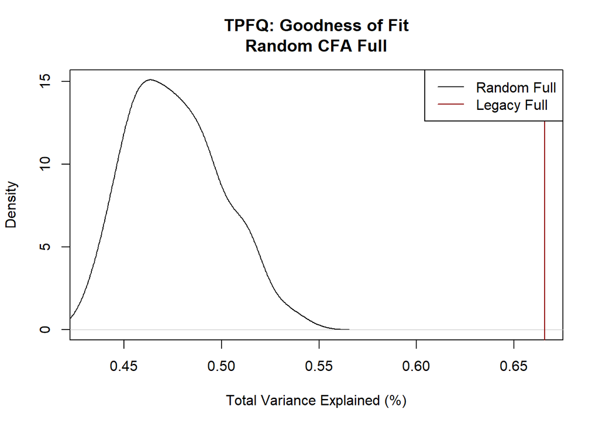

```r
# CFA Full
plot(density(rand_gof$full)
     , xlim=get_lims(c(rand_gof$full, legacy_gof["full"]))
     , xlab=gof_lookup[["desc"]][gof_type], main=paste0(itab, ": Goodness of Fit\nRandom CFA Full")
)
abline(v=legacy_gof["full"], col="darkred")
legend("topright"
       , legend=c("Random Full", "Legacy Full")
       , col=c("black", "darkred")
       , lty = c(1,1))
```

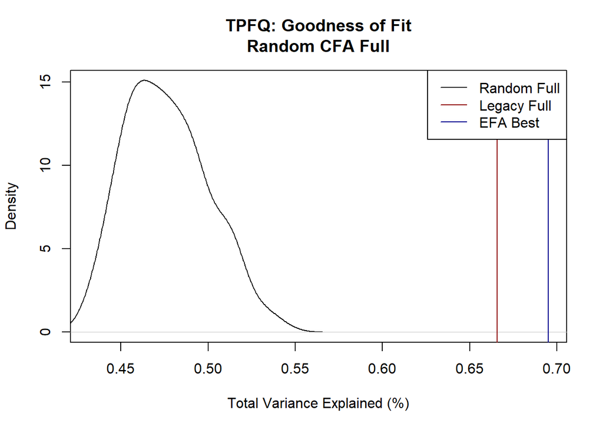

```r
# CFA Full
plot(density(rand_gof$full)
     , xlim=get_lims(c(rand_gof$full, legacy_gof["full"], efa_gof[best_efa_id]))
     , xlab=gof_lookup[["desc"]][gof_type], main=paste0(itab, ": Goodness of Fit\nRandom CFA Full")
)
abline(v=legacy_gof["full"], col="darkred")
abline(v=efa_gof[best_efa_id], col="darkblue")
legend("topright"
       , legend=c("Random Full", "Legacy Full", "EFA Best")
       , col=c("black", "darkred", "darkblue")
       , lty = c(1,1))
```

**CFA Reduced:** Compared to 100 randomly generated subscales, how well does legacy perform? In both cases we use ‘reduced’ model above. *Purpose* Is the legacy subscale better than choosing a subscale at random? How much better?

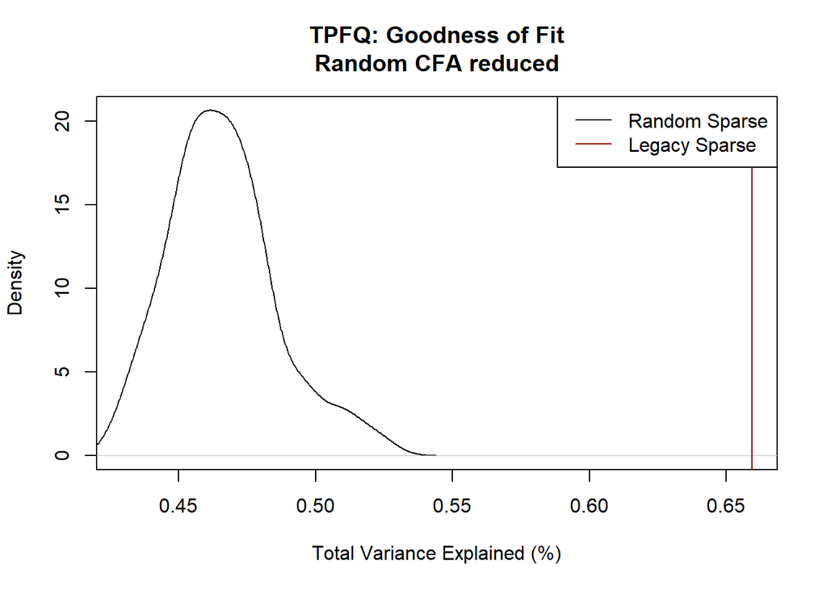

```r
# CFA reduced
plot(density(rand_gof$reduced)
     , xlim=get_lims(c(rand_gof$reduced, legacy_gof["reduced"]))
     , xlab=gof_lookup[["desc"]][gof_type], main=paste0(itab, ": Goodness of Fit\nRandom CFA reduced")
)
abline(v=legacy_gof["reduced"], col="darkred")
legend("topright"
       , legend=c("Random Sparse", "Legacy Sparse")
       , col=c("black", "darkred")
       , lty = c(1,1))
```

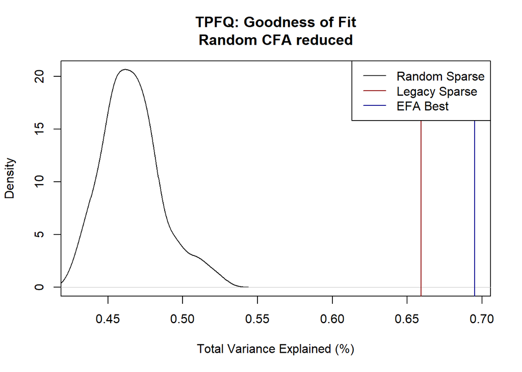

```r
# CFA reduced
plot(density(rand_gof$reduced)
     , xlim=get_lims(c(rand_gof$reduced, legacy_gof["reduced"], efa_gof[best_efa_id]))
     , xlab=gof_lookup[["desc"]][gof_type], main=paste0(itab, ": Goodness of Fit\nRandom CFA reduced")
)
abline(v=legacy_gof["reduced"], col="darkred")
abline(v=efa_gof[best_efa_id], col="darkblue")
legend("topright"
       , legend=c("Random Sparse", "Legacy Sparse", "EFA Best")
       , col=c("black", "darkred", "darkblue")
       , lty = c(1,1))
```

**Individual factors:** How well does each factor explain its corresponding items? Note that different factors have different numbers of items and this impacts goodness of fit.

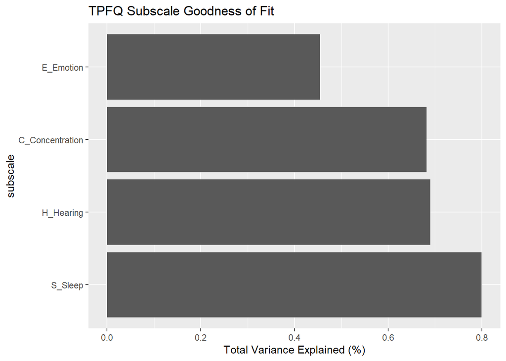

```r
df_out = data.frame(
  id=rownames(legacy_one_gof)
  , gof=legacy_one_gof$reduced # / colSums(ilookup[,-c(1,2)]) # Division important
  , stringsAsFactors = FALSE
)
df_out = df_out[order(df_out$gof, decreasing = TRUE),]
df_out$id = factor(df_out$id, levels=df_out$id)
ggplot(df_out, aes(x=id, y=gof)) + geom_bar(stat="identity") + labs(x="subscale", y = gof_lookup[["desc"]][gof_type], title=paste0(itab, " Subscale Goodness of Fit")) +   coord_flip()
```

```r
data.frame(
  itab=c(
    "Random Subscale (95%)"=paste0("[", paste(round(quantile(rand_gof$reduced,c(0.025,0.975)),3), collapse=", "), "]")
    , "Legacy Subscale"=round(legacy_gof["reduced"],3)
    , "EFA Subscale"=round(efa_gof[best_efa_id],3)
    , "CFA Factors (#)"=ncol(iresults$ilookup)-2
    , "EFA Factors (#)"=best_efa_id
  )

)
```

```
##                                   itab
## Random Subscale (95%)   [0.433, 0.511]
## Legacy Subscale.reduced          0.659
## EFA Subscale                     0.695
## CFA Factors (#)                      4
## EFA Factors (#)                      4
```

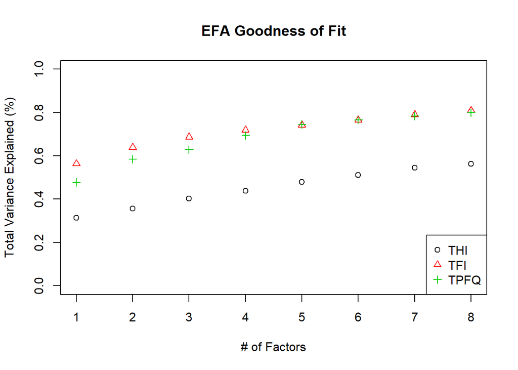

```r
efa_gof_all = do.call(cbind, lapply(
  results
  , function(iresults) sapply(iresults$efa, get_efa_gof, gof_type=gof_type)
))
plot(x=NA, y=NA, xlim=c(1,8), ylim=c(0,1)
     , xlab="# of Factors"
     , ylab=gof_lookup[["desc"]][gof_type]
     , main="EFA Goodness of Fit")
for (i in 1:ncol(efa_gof_all)){
  points(1:8, efa_gof_all[,i], col=i, pch=i)
}
legend("bottomright"
       , legend=colnames(efa_gof_all)
       , col=1:ncol(efa_gof_all)
       # , lty = c(0,1,1)
       , pch =1:ncol(efa_gof_all)
)
```

Misc…

```r
# sapply(iresults$efa, function(x) x$dof)
# c(nrow(parameterEstimates(results$THI$cfa$reduced$legacy, remove.nonfree = TRUE)), nrow(parameterEstimates(results$TFI$cfa$reduced$legacy, remove.nonfree = TRUE)), nrow(parameterEstimates(results$TPFQ$cfa$reduced$legacy, remove.nonfree = TRUE)))
```